# Toxic Comment Classification Challenge

[figure not shown]

💡 📢 ☑️ remember to read the **`readme.md`** file for helpful hints on the best ways to view/navigate this project

**If you visualize this notebook on github you will be missing important content**

Some charts/diagrams/features are not visible in github. This is [standard and well-known behaviour](https://blog.jupyter.org/rendering-notebooks-on-github-f7ac8736d686).

Consider viewing the pre-rendered HTML files, or run all notebooks end to end after enabling the feature flags that control long running operations:

**If you chose to run this locally**, there are some prerequisites:

- you will need `python 3.9`
- you will need to install the dependencies using `pip install -r requirements.txt` before proceeding.

## Problem Statement (provided by Turing College)

```
Module 4: Deep Learning
=======================
Sprint 2: Natural Language Processing - Toxic comment challenge
---------------------------------------------------------------

The time has come again to put together all we learned in the previous lessons and try to tackle a real-life issue.

In this project, we will try to put ourselves into the shoes of content moderators. Every online platform which has an open forum faces an issue of people posting inappropriate comments, which if uncontrolled, can lead to loss of users, reputation and revenue. However, it is impractical and expensive for humans to keep track of all the messages other people post. Luckily, ML is here to help. We can train a model to automatically analyze all the messages users write and flag toxic users/comments so that appropriate actions can be taken.

We will use Kaggle toxic comment dataset <https://www.kaggle.com/c/jigsaw-toxic-comment-classification-challenge>

Your task today is to build a **multi-label** classifier, to assign forum posts to one or more of the 6 classes.

* * * * *

Multi-label classification
--------------------------

Up until now all, of the classification exercises we have seen were *multi-class* (e.g. dog, cat, plane) or binary (e.g. yes/no). Both methods are used when there is only 1 right answer, e.g. an animal cannot be both a dog and a plane. In *multi-label* classification, each input can result in many possible answers, e.g. articles could have a mixture of tags: news, sports, politics.
```

[figure not shown]

```
Source: https://theailearner.com/2019/07/15/multi-label-classification/

So what are the implications for the neural network, that you are going to build?

1. You cannot use softmax any more, since it makes a probability distribution over all of the classes. This time we need each output to have its own and independent probability. A good way to do it is to apply a Sigmoid activation to the output layer, which will squash your output between 0 and 1, thus you can treat the output as a probability to a sample belonging to a class
2. We need to change our loss function. Cross-entropy loss is used for multi-class problems, so you will have to change it to Binary Cross-entropy since we want each output considered individually.
3. Your labels will now have to be 1-hot-encoded. Since each output can have various labels, it is a good way to represent it. So a label, that belongs to class 1 and 4 out of possible 5, will be represented as `[0, 1, 0, 0, 1, 0]`. You can use sklearn [one-hot-encoder](https://scikit-learn.org/stable/modules/generated/sklearn.preprocessing.OneHotEncoder.html) to easily convert your labels
4. When using model outputs (e.g. predictions in prod, evaluation), you will need to threshold the output. Why? Consider how a multi-label output with sigmoid activation from your model will look. For a 5 label problem, it will be a vector with 5 values, each from 0 to 1, e.g. `[0.01, 0.99, 0.68, 0.89, 0.32]`. How do you convert this into yes/no for each label? By applying a threshold of some value, such as 0.5. Meaning if the probability is less than 50%, we say it does not belong to this class. If more than 50% then it does, which will convert the above output to `[0, 1, 1, 1, 0]`

You can use HuggingFace transformers library and adapt a *{TRANSFORMER}*ForSequenceClassification method. I recommend using [DistilBERT](https://huggingface.co/transformers/model_doc/distilbert.html#distilbertforsequenceclassification) or [RoBERTa](https://huggingface.co/transformers/model_doc/roberta.html#robertaforsequenceclassification). You will have to make sure you don't pass labels to the classifier and calculate it yourself in the model.

EDA
---

Since your time is very limited and the task is not trivial, do not spend time doing extensive EDA. It is a very important step in every project and you will have to do some, in order to understand how many classes you have, what the text data looks like, potentially the class distribution. But avoid spending more than an hour on this, since you want to leave the maximum time for building a model and preprocessing data.

Concepts to explore
-------------------

- Multi-label classification
- Binary cross-entropy loss

Requirements
------------

- EDA
- Preprocess your data correctly, including converting labels to one-hot-encoding
- Split data into train/validation/test sets
- Visualize model performance
- Ensure your work has written conclusions and insights about
    - Main details about the data
    - Model considerations and implementation
    - Results
    - Recommendations for improvements

Evaluation criteria
-------------------

When solving this problem, ensure that you plan your time carefully. The most important part is to show your NLP and deep learning knowledge. Meaning, ensure you build a model with correct output, loss, and activations as well as do the correct data preprocessing pipeline (e.g. text tokenization, one-hot-encoding of labels).

Model performance
- Correctly preprocessed labels
- Correctly built model
- End-to-end trainable model
- Model performance
- Code quality

Bonus challenges
----------------

- Add class weights to BCE loss. To calculate those weights refer to [here](https://scikit-learn.org/stable/modules/generated/sklearn.utils.class_weight.compute_sample_weight.html)
- Use tanh activation for the output layer and compare results with sigmoid. Note, you will have to change your data preprocessing pipeline since tanh has a different activation range. Investigate what it is and adapt your solution.

Sample correction questions
---------------------------

During a correction, you may get asked questions that test your understanding of covered topics.

- What is tokenization in NLP context and why is it important?
- What is attention mechanism in transformers and what are its main advantage(s)
- What are the differences between GPT and BERT transformers
- Explain in a high level - how does a character-based generative model work?
```

[output not shown]

You can check out the table of contents on the left hand panel in JupyterLab

[figure not shown]

# Getting Started

💡 After receiving feedback in past project that I tend to murder my reviewers by going too in depth, with excessive detail and explaining too many things, I will try to keep the descriptions for "what I'm thinking/considering" a bit more concise. Happy to hear your feedback.

## Imports and initial setup

```python
from IPython.display import display, Markdown, clear_output, HTML, IFrame
import matplotlib.pyplot as plt
from mpl_toolkits.mplot3d import Axes3D
from matplotlib.colors import ListedColormap
import itertools
import glob

import numpy as np
import pandas as pd
import seaborn as sns

import torch
from torch import nn
from torch.utils.data import DataLoader, random_split, WeightedRandomSampler
from torchvision import transforms, datasets, models
import torch.nn.functional as F
from torchmetrics.classification import (
    MulticlassConfusionMatrix,
    MulticlassAccuracy,
    MulticlassPrecision,
    MulticlassRecall,
    MulticlassF1Score,
)
from torchmetrics import ConfusionMatrix

from PIL import Image, ImageDraw, ImageFile
import plotly.express as px
import plotly.io as pio
from scipy.stats import chi2_contingency, chisquare
import missingno as msno

from sklearn.feature_extraction.text import CountVectorizer
from sklearn.metrics import (
    precision_score,
    recall_score,
    f1_score,
    roc_curve,
    auc,
    ConfusionMatrixDisplay,
)

from transformers import TrainingArguments
from transformers import Trainer

import string


from random import random, seed, shuffle
import logging
import warnings

import os
from os import path

from utils import *
from utils import __
```

```python
from datasets import load_dataset
from datasets.dataset_dict import DatasetDict
from datasets import load_metric
from datasets.features.features import Features, ClassLabel, Value

from transformers import AutoModelForSequenceClassification
from transformers import AutoTokenizer, DataCollatorWithPadding
```

```python
print(f"{np.__version__    = }")
print(f"{pd.__version__    = }")
print(f"{torch.__version__ = }")
```

```
np.__version__    = '1.23.5'
pd.__version__    = '2.1.4'
torch.__version__ = '2.1.0+cu121'
```

```python
seed(100)
pd.options.display.max_rows = 100
pd.options.display.max_colwidth = 50

util.check("done")
```

```
✅
```

Let's use `black` to auto-format all our cells so they adhere to PEP8

```python
import lab_black

%reload_ext lab_black
util.patch_nb_black()
# fmt: off
# fmt: on
```

```python
from sklearn import set_config

set_config(transform_output="pandas")
```

```python
sns.set_theme(context="notebook", style="whitegrid")

moonstone = "#62b6cb"
moonstone_rgb = util.hex_to_rgb(moonstone)
moonstone_rgb_n = np.array(moonstone_rgb) / 255
```

```python
logger = util.configure_logging(jupyterlab_level=logging.WARN, file_level=logging.DEBUG)

warnings.filterwarnings("ignore", category=FutureWarning)

# import warnings
# warnings.filterwarnings('error', category=pd.errors.DtypeWarning)
```

### Configure logging

Thanks [kkalera](https://github.com/kkalera/DataScienceTemplate/blob/main/template.ipynb) for this great snippet

```python
# kkalera's logger config
logger = logging.getLogger()
logger.setLevel(logging.INFO)

formatter = logging.Formatter("%(asctime)s - %(name)s - %(levelname)s - %(message)s")

file_handler = logging.FileHandler("notebook_logging.log")
file_handler.setLevel(logging.INFO)
file_handler.setFormatter(formatter)

stream_handler = logging.StreamHandler()
stream_handler.setLevel(logging.INFO)
stream_handler.setFormatter(formatter)

logger.addHandler(file_handler)
logger.addHandler(stream_handler)
```

```python
def ding(title="Ding!", message="Task completed"):
    """
    this method only works on linux
    """
    for i in range(2):
        !notify-send '{title}' '{message}'
```

## Feature Toggles

Let's also create a simple feature toggle that we can use to skip expensive operations during notebook work (to save myself some time!)

Set it to true if you want to run absolutely everything. Set to false to skip optional steps/exploratory work.

```python
def run_entire_notebook(filename: str = None):
    run_all = False
    if not run_all:
        print("skipping optional operation")
        fullpath = f"cached/printouts/{filename}.txt"
        if filename is not None and os.path.exists(fullpath):
            print("==== 🗃️ printing cached output ====")
            with open(fullpath) as f:
                print(f.read())
    return run_all
```

# Fetching Data

```python
kaggle_dataset_name = "jigsaw-toxic-comment-classification-challenge"
db_filename = "train.csv"

auto_kaggle.download_dataset(
    kaggle_dataset_name, db_filename, timeout_seconds=3 * 60, is_competition=True
)
__
```

```
Kaggle API 1.5.13 - login as 'edualmas'
File [dataset/train.csv] already exists locally!
No need to re-download data for competition [jigsaw-toxic-comment-classification-challenge]
```

For reproducibility, the dataset is also available [from a number of public repos](https://github.com/tianqwang/Toxic-Comment-Classification-Challenge/tree/master/data) without requiring kaggle credentials/registration.

```python
!ls -lh dataset/*.csv
```

```
-rw-rw-r-- 1 edu edu 6,0M de des.  20 19:20 dataset/sample_submission.csv
-rw-rw-r-- 1 edu edu  58M de des.  20 19:20 dataset/test.csv
-rw-rw-r-- 1 edu edu 4,8M de des.  20 19:20 dataset/test_labels.csv
-rw-rw-r-- 1 edu edu  66M de des.  20 19:20 dataset/train.csv
```

# Exploratory Data Analysis

Let's take a look at the files we have and what they contain:

```python
train_raw = pd.read_csv("dataset/train.csv")
train_raw.head(20)
```

|  | id | comment_text | toxic | severe_toxic | obscene | threat | insult | identity_hate |
| --- | --- | --- | --- | --- | --- | --- | --- | --- |
| 0 | 0000997932d777bf | Explanation\nWhy the edits made under my usern... | 0 | 0 | 0 | 0 | 0 | 0 |
| 1 | 000103f0d9cfb60f | D'aww! He matches this background colour I'm s... | 0 | 0 | 0 | 0 | 0 | 0 |
| 2 | 000113f07ec002fd | Hey man, I'm really not trying to edit war. It... | 0 | 0 | 0 | 0 | 0 | 0 |
| 3 | 0001b41b1c6bb37e | "\nMore\nI can't make any real suggestions on ... | 0 | 0 | 0 | 0 | 0 | 0 |
| 4 | 0001d958c54c6e35 | You, sir, are my hero. Any chance you remember... | 0 | 0 | 0 | 0 | 0 | 0 |
| 5 | 00025465d4725e87 | "\n\nCongratulations from me as well, use the ... | 0 | 0 | 0 | 0 | 0 | 0 |
| 6 | 0002bcb3da6cb337 | COCKSUCKER BEFORE YOU PISS AROUND ON MY WORK | 1 | 1 | 1 | 0 | 1 | 0 |
| 7 | 00031b1e95af7921 | Your vandalism to the Matt Shirvington article... | 0 | 0 | 0 | 0 | 0 | 0 |
| 8 | 00037261f536c51d | Sorry if the word 'nonsense' was offensive to ... | 0 | 0 | 0 | 0 | 0 | 0 |
| 9 | 00040093b2687caa | alignment on this subject and which are contra... | 0 | 0 | 0 | 0 | 0 | 0 |
| 10 | 0005300084f90edc | "\nFair use rationale for Image:Wonju.jpg\n\nT... | 0 | 0 | 0 | 0 | 0 | 0 |
| 11 | 00054a5e18b50dd4 | bbq \n\nbe a man and lets discuss it-maybe ove... | 0 | 0 | 0 | 0 | 0 | 0 |
| 12 | 0005c987bdfc9d4b | Hey... what is it..\n@ \| talk .\nWhat is it...... | 1 | 0 | 0 | 0 | 0 | 0 |
| 13 | 0006f16e4e9f292e | Before you start throwing accusations and warn... | 0 | 0 | 0 | 0 | 0 | 0 |
| 14 | 00070ef96486d6f9 | Oh, and the girl above started her arguments w... | 0 | 0 | 0 | 0 | 0 | 0 |
| 15 | 00078f8ce7eb276d | "\n\nJuelz Santanas Age\n\nIn 2002, Juelz Sant... | 0 | 0 | 0 | 0 | 0 | 0 |
| 16 | 0007e25b2121310b | Bye! \n\nDon't look, come or think of comming ... | 1 | 0 | 0 | 0 | 0 | 0 |
| 17 | 000897889268bc93 | REDIRECT Talk:Voydan Pop Georgiev- Chernodrinski | 0 | 0 | 0 | 0 | 0 | 0 |
| 18 | 0009801bd85e5806 | The Mitsurugi point made no sense - why not ar... | 0 | 0 | 0 | 0 | 0 | 0 |
| 19 | 0009eaea3325de8c | Don't mean to bother you \n\nI see that you're... | 0 | 0 | 0 | 0 | 0 | 0 |

Let's also check out the test files.. Sometimes they are missing actual labels and they are unusable...

```python
test_raw = pd.read_csv("dataset/test.csv")
test_raw
```

|  | id | comment_text |
| --- | --- | --- |
| 0 | 00001cee341fdb12 | Yo bitch Ja Rule is more succesful then you'll... |
| 1 | 0000247867823ef7 | == From RfC == \n\n The title is fine as it is... |
| 2 | 00013b17ad220c46 | " \n\n == Sources == \n\n * Zawe Ashton on Lap... |
| 3 | 00017563c3f7919a | :If you have a look back at the source, the in... |
| 4 | 00017695ad8997eb | I don't anonymously edit articles at all. |
| ... | ... | ... |
| 153159 | fffcd0960ee309b5 | . \n i totally agree, this stuff is nothing bu... |
| 153160 | fffd7a9a6eb32c16 | == Throw from out field to home plate. == \n\n... |
| 153161 | fffda9e8d6fafa9e | " \n\n == Okinotorishima categories == \n\n I ... |
| 153162 | fffe8f1340a79fc2 | " \n\n == ""One of the founding nations of the... |
| 153163 | ffffce3fb183ee80 | " \n :::Stop already. Your bullshit is not wel... |

153164 rows × 2 columns

```python
test_labels_raw = pd.read_csv("dataset/test_labels.csv")
test_labels_raw
```

|  | id | toxic | severe_toxic | obscene | threat | insult | identity_hate |
| --- | --- | --- | --- | --- | --- | --- | --- |
| 0 | 00001cee341fdb12 | -1 | -1 | -1 | -1 | -1 | -1 |
| 1 | 0000247867823ef7 | -1 | -1 | -1 | -1 | -1 | -1 |
| 2 | 00013b17ad220c46 | -1 | -1 | -1 | -1 | -1 | -1 |
| 3 | 00017563c3f7919a | -1 | -1 | -1 | -1 | -1 | -1 |
| 4 | 00017695ad8997eb | -1 | -1 | -1 | -1 | -1 | -1 |
| ... | ... | ... | ... | ... | ... | ... | ... |
| 153159 | fffcd0960ee309b5 | -1 | -1 | -1 | -1 | -1 | -1 |
| 153160 | fffd7a9a6eb32c16 | -1 | -1 | -1 | -1 | -1 | -1 |
| 153161 | fffda9e8d6fafa9e | -1 | -1 | -1 | -1 | -1 | -1 |
| 153162 | fffe8f1340a79fc2 | -1 | -1 | -1 | -1 | -1 | -1 |
| 153163 | ffffce3fb183ee80 | -1 | -1 | -1 | -1 | -1 | -1 |

153164 rows × 7 columns

It seems that this last file was added after the competition ended, and it contains the true labels for each of the messages in the test split. NOPE! This file does not contain the true labels, this file contains a marker indicating whether a specific message was used during the scoring of submissions to kaggle (not all of the messages counted towards the score).

This means that we cannot actually use the test files.

- The test.csv is useless without the correct labels
- The test_labels.csv does not contain labels and was only released for transparency around how scores were calculated.

**We are down to just being able to use train.csv**... disappointed, but not surprised.

We don't even need to check the sample_csv because it is just included as an example.... but we might as well do it for completion, even though, clearly, this file is not for us and won't be used in this project.

```python
sample_submission_raw = pd.read_csv("dataset/sample_submission.csv")
sample_submission_raw.head()
```

|  | id | toxic | severe_toxic | obscene | threat | insult | identity_hate |
| --- | --- | --- | --- | --- | --- | --- | --- |
| 0 | 00001cee341fdb12 | 0.5 | 0.5 | 0.5 | 0.5 | 0.5 | 0.5 |
| 1 | 0000247867823ef7 | 0.5 | 0.5 | 0.5 | 0.5 | 0.5 | 0.5 |
| 2 | 00013b17ad220c46 | 0.5 | 0.5 | 0.5 | 0.5 | 0.5 | 0.5 |
| 3 | 00017563c3f7919a | 0.5 | 0.5 | 0.5 | 0.5 | 0.5 | 0.5 |
| 4 | 00017695ad8997eb | 0.5 | 0.5 | 0.5 | 0.5 | 0.5 | 0.5 |

Let's remove these variables from memory so we cannot use them accidentally.

```python
del test_raw
del test_labels_raw
del sample_submission_raw
```

## Splitting our data

Since we cannot use the `test*.csv` files from kaggle, because they are missing the target labels, we must split our 150k row dataset into a few smaller chunks.

First, let's take a look at the spread of labels, so we get a rough idea about the imbalance

```python
labels = ["toxic", "severe_toxic", "obscene", "threat", "insult", "identity_hate"]
```

```python
ordered_labels = train_raw[labels].sum().sort_values(ascending=False)
ordered_labels
```

```
toxic            15294
obscene           8449
insult            7877
severe_toxic      1595
identity_hate     1405
threat             478
dtype: int64
```

```python
ordered_labels = ordered_labels.index
```

```
(0.0, 1.0)
```

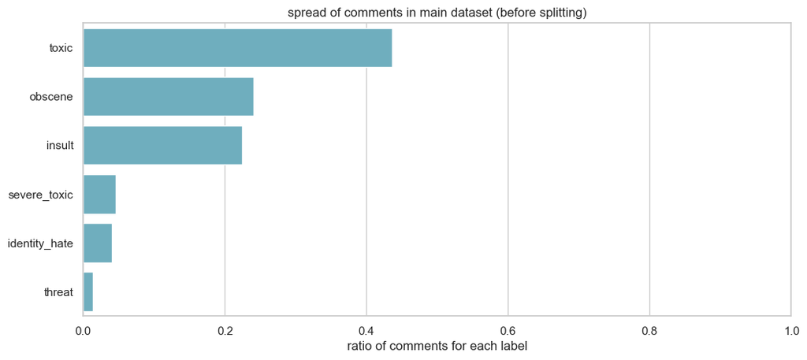

```python
plt.figure(figsize=(12, 5))
sns.barplot(
    y=labels,
    x=train_raw[labels].sum() / train_raw[labels].sum().sum(),
    color=moonstone,
    order=ordered_labels,
)
plt.title("spread of comments in main dataset (before splitting)")
plt.xlabel("ratio of comments for each label")
plt.xlim(0, 1)
```

```python
@cached_dataframes(gitignored=True)
def dataset_split():
    splits = split_utils.split_dataset(
        df=train_raw,
        target_cols=labels,
        split_sizes={"train": 0.70, "hp": 0.10, "val": 0.10, "test": 0.10},
        stratify_labels=False,
        rnd=42,
    )
    return {
        "train_X": splits["train"][0],
        "train_y": splits["train"][1],
        "hp_X": splits["hp"][0],
        "hp_y": splits["hp"][1],
        "val_X": splits["val"][0],
        "val_y": splits["val"][1],
        "test_X": splits["test"][0],
        "test_y": splits["test"][1],
    }
```

With this, the split is persisted to disk once the first time this notebook is run, and all future re-runs will reload the exact same split.

The splits are stored on disk and are consistent across system reboots. This is one way to guarantee that there will be no issues around accidental data leakage.

Let's double-check and make sure that the datasplits are shuffled properly and still have similar patterns

```python
splits = dataset_split()
__
```

```
Loading from cache [./cached/df_dict/dataset_split.h5.gitignored]
```

```python
ratios = pd.DataFrame(
    {
        "train": splits["train_y"].sum(),
        "hp": splits["hp_y"].sum(),
        "val": splits["val_y"].sum(),
        "test": splits["test_y"].sum(),
    }
)
ratios
```

|  | train | hp | val | test |
| --- | --- | --- | --- | --- |
| toxic | 10712 | 1527 | 1507 | 1548 |
| severe_toxic | 1109 | 156 | 156 | 174 |
| obscene | 5893 | 859 | 831 | 866 |
| threat | 342 | 49 | 42 | 45 |
| insult | 5488 | 793 | 767 | 829 |
| identity_hate | 973 | 133 | 144 | 155 |

```python
ratios = ratios / ratios.sum()
ratios
```

|  | train | hp | val | test |
| --- | --- | --- | --- | --- |
| toxic | 0.436921 | 0.434177 | 0.437192 | 0.427979 |
| severe_toxic | 0.045234 | 0.044356 | 0.045257 | 0.048106 |
| obscene | 0.240364 | 0.244242 | 0.241079 | 0.239425 |
| threat | 0.013950 | 0.013932 | 0.012185 | 0.012441 |
| insult | 0.223845 | 0.225476 | 0.222512 | 0.229195 |
| identity_hate | 0.039687 | 0.037816 | 0.041775 | 0.042853 |

```python
ratios = ratios.reset_index(names="label").melt(
    id_vars="label",
    var_name="split",
)
ratios.head(10)
```

|  | label | split | value |
| --- | --- | --- | --- |
| 0 | toxic | train | 0.436921 |
| 1 | severe_toxic | train | 0.045234 |
| 2 | obscene | train | 0.240364 |
| 3 | threat | train | 0.013950 |
| 4 | insult | train | 0.223845 |
| 5 | identity_hate | train | 0.039687 |
| 6 | toxic | hp | 0.434177 |
| 7 | severe_toxic | hp | 0.044356 |
| 8 | obscene | hp | 0.244242 |
| 9 | threat | hp | 0.013932 |

```
(0.0, 1.0)
```

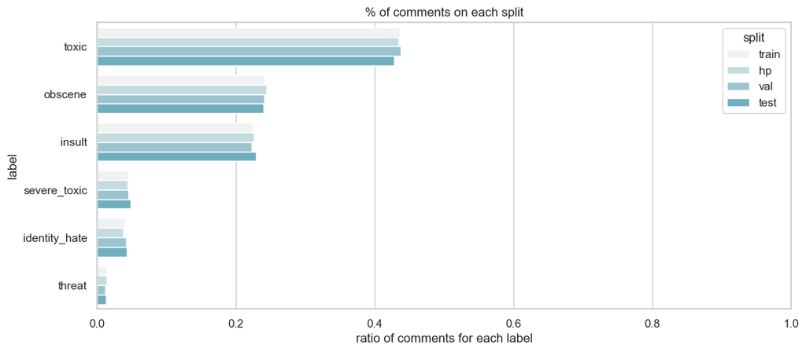

```python
plt.figure(figsize=(12, 5))
sns.barplot(
    ratios, y="label", x="value", hue="split", color=moonstone, order=ordered_labels
)
plt.title("% of comments on each split")
plt.xlabel("ratio of comments for each label")
plt.xlim(0, 1)
```

Despite having disable stratification of our datasets (because it was struggling due to the few unique combinations), we still get a pretty good shuffling with a similar % of classes in each of the splits.

We're happy about this.

## Visualizing patterns in the messages

Let's take a look at the ratios of comments we have:

```python
splits["hp_y"].value_counts()
```

```
toxic  severe_toxic  obscene  threat  insult  identity_hate
0      0             0        0       0       0                14322
1      0             0        0       0       0                  547
                     1        0       1       0                  391
                                      0       0                  186
                     0        0       1       0                  123
       1             1        0       1       0                  100
       0             1        0       1       1                   50
0      0             0        0       1       0                   41
                     1        0       0       0                   35
1      1             1        0       1       1                   25
       0             0        0       0       1                   19
       1             1        0       0       0                   18
0      0             1        0       1       0                   16
1      0             1        1       1       0                   14
```

[output cut: 18 more lines]

It seems that the vast majority of comments are not flagged, and that there's a minority of problematic comments.

Let's use missingno to visualize the patterns inside the flagged comments. Since missingno only cares about NAs, we will replace one of the values (safe comment) for NA, so it appears white. The toxic comments will be coloured in blue.

```python
flagged = splits["hp_y"].map(lambda x: x if x != 0 else np.NaN).notna().any(axis=1)
```

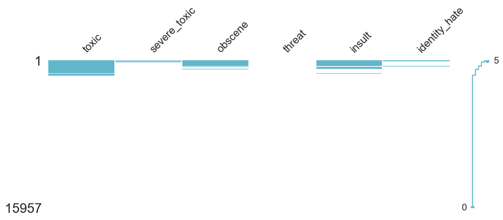

```python
msno.matrix(
    splits["hp_y"].map(lambda x: x if x != 0 else np.NaN),
    figsize=(12, 4),
    sort="descending",
    color=moonstone_rgb_n,
)
```

There are so few "threat" comments that missingo cannot even draw 1-pixel high line...

This is an **extremely imbalanced dataset**, which will affect how we should measure its performance, later.

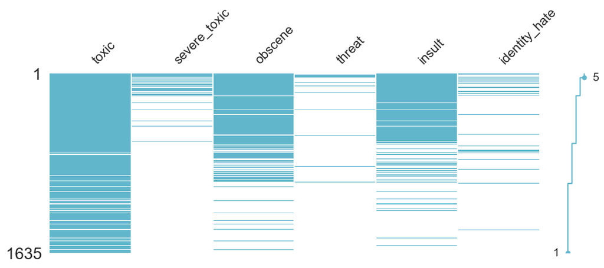

```python
msno.matrix(
    splits["hp_y"].map(lambda x: x if x != 0 else np.NaN)[flagged],
    figsize=(12, 4),
    sort="descending",
    color=moonstone_rgb_n,
)
```

It seems that, in the rare cases where a comment is flagged, toxic is the most common subtype, and that it has a strong overlap with either obscenety or insults.

## Assessing letter frequency

If the majority of comments are written in english, we would expect the overall character frequencies to match that of english language

source:

- [sttmedia.com](https://www.sttmedia.com/characterfrequency-english) (❌ nope! the values do not add up to 100%)
- [wikipedia.org](https://en.wikipedia.org/wiki/Letter_frequency#Relative_frequencies_of_letters_in_the_English_language) (❌ nope! the values do not add up to 100%)
- [Notre Damme University](https://www3.nd.edu/~busiforc/handouts/cryptography/letterfrequencies.html) (finally! Values do add up to ~100% almost!) ✅

```python
eng_freq = pd.read_csv("eng_letter_frequency.csv", index_col=0, decimal=".")
eng_freq.index = eng_freq.index.str.upper()
eng_freq = eng_freq / 100
eng_freq.head()
```

| letter | frequency |
| --- | --- |
| A | 0.084966 |
| B | 0.020720 |
| C | 0.045388 |
| D | 0.033844 |
| E | 0.111607 |

```python
eng_freq.frequency.sum()
```

```
0.9999999999999999
```

```python
def plot_letter_frequency(letter_frequency):
    plt.figure(figsize=(10, 6))
    sns.barplot(
        y=letter_frequency.index,
        x=letter_frequency * 100,
        color=moonstone,
        order=letter_frequency.sort_values(ascending=False).index,
    )
    plt.xlabel("frequency (%)")
```

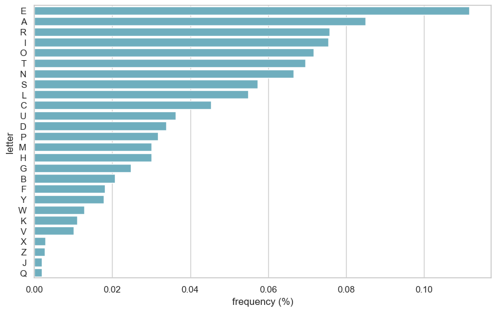

```python
plot_letter_frequency(eng_freq.frequency / 100)
```

```python
vectorizer = CountVectorizer(analyzer="char", vocabulary=list(string.ascii_lowercase))

texts = splits["hp_X"].comment_text

X_transformed = vectorizer.fit_transform(texts)
X_transformed = X_transformed.toarray()
```

```python
letter_count = pd.DataFrame(X_transformed, columns=list(string.ascii_uppercase))
actual_counts = letter_count.sum()
total_count = actual_counts.sum()
expected_counts = eng_freq.frequency * total_count
```

```python
chi2, p_val = chisquare(actual_counts, f_exp=expected_counts)
chi2, p_val
```

```
(205700.24751618612, 0.0)
```

```python
pd.DataFrame(
    {
        "expected": expected_counts,
        "actual": actual_counts,
        "diff": expected_counts - actual_counts,
        "diff^2": (expected_counts - actual_counts) ** 2,
        "chi2_term": ((expected_counts - actual_counts) ** 2) / expected_counts,
    }
)
```

|  | expected | actual | diff | diff^2 | chi2_term |
| --- | --- | --- | --- | --- | --- |
| A | 412893.97632 | 396551 | 16342.97632 | 2.670929e+08 | 646.880047 |
| B | 100689.25440 | 77834 | 22855.25440 | 5.223627e+08 | 5187.868922 |
| C | 220563.89376 | 151155 | 69408.89376 | 4.817595e+09 | 21842.172129 |
| D | 164465.59488 | 179408 | -14942.40512 | 2.232755e+08 | 1357.581632 |
| E | 542356.44864 | 574476 | -32119.55136 | 1.031666e+09 | 1902.191045 |
| F | 88059.36192 | 95016 | -6956.63808 | 4.839481e+07 | 549.570339 |
| G | 120054.44160 | 100008 | 20046.44160 | 4.018598e+08 | 3347.313231 |
| H | 145950.82368 | 220830 | -74879.17632 | 5.606891e+09 | 38416.302868 |
| I | 366641.06496 | 392766 | -26124.93504 | 6.825122e+08 | 1861.526970 |
| J | 9548.95680 | 10561 | -1012.04320 | 1.024231e+06 | 107.261082 |
| K | 53532.47232 | 53928 | -395.52768 | 1.564421e+05 | 2.922378 |
| L | 266753.63136 | 198016 | 68737.63136 | 4.724862e+09 | 17712.456025 |
| M | 146412.47808 | 118223 | 28189.47808 | 7.946467e+08 | 5427.451846 |
| N | 323371.89888 | 328485 | -5113.10112 | 2.614380e+07 | 80.847480 |
| O | 348111.71520 | 386566 | -38454.28480 | 1.478732e+09 | 4247.866288 |
| P | 153905.85792 | 107757 | 46148.85792 | 2.129717e+09 | 13837.790946 |
| Q | 9534.37824 | 5316 | 4218.37824 | 1.779471e+07 | 1866.373929 |
| R | 368395.35168 | 275944 | 92451.35168 | 8.547252e+09 | 23201.303677 |
| S | 278698.33152 | 311951 | -33252.66848 | 1.105740e+09 | 3967.515539 |
| T | 337780.37568 | 453286 | -115505.62432 | 1.334155e+10 | 39497.703864 |
| U | 176434.59264 | 155351 | 21083.59264 | 4.445179e+08 | 2519.448550 |
| V | 48954.80448 | 51254 | -2299.19552 | 5.286300e+06 | 107.983273 |
| W | 62682.94848 | 88214 | -25531.05152 | 6.518346e+08 | 10398.914019 |
| X | 14102.32704 | 9542 | 4560.32704 | 2.079658e+07 | 1474.691564 |
| Y | 86397.40608 | 107480 | -21082.59392 | 4.444758e+08 | 5144.549895 |
| Z | 13227.61344 | 9602 | 3625.61344 | 1.314507e+07 | 993.759976 |

```python
letter_count = pd.DataFrame(X_transformed, columns=list(string.ascii_lowercase))
actual_frequency = letter_count.sum() / letter_count.sum().sum()
actual_frequency.index = actual_frequency.index.str.upper()
actual_frequency
```

```
A    0.081603
B    0.016017
C    0.031105
D    0.036919
E    0.118217
F    0.019553
G    0.020580
H    0.045443
I    0.080824
J    0.002173
K    0.011097
L    0.040748
M    0.024328
N    0.067596
O    0.079548
P    0.022174
Q    0.001094
R    0.056784
S    0.064194
T    0.093278
U    0.031968
V    0.010547
W    0.018153
X    0.001964
Y    0.022117
Z    0.001976
dtype: float64
```

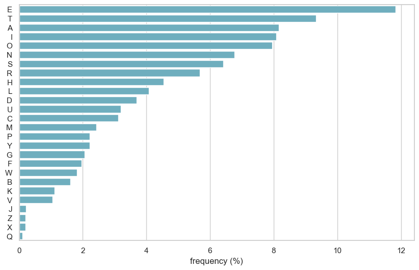

```python
plot_letter_frequency(actual_frequency)
```

```python
actual_frequency
```

```
A    0.081603
B    0.016017
C    0.031105
D    0.036919
E    0.118217
F    0.019553
G    0.020580
H    0.045443
I    0.080824
J    0.002173
K    0.011097
L    0.040748
M    0.024328
N    0.067596
O    0.079548
P    0.022174
Q    0.001094
R    0.056784
S    0.064194
T    0.093278
U    0.031968
V    0.010547
W    0.018153
X    0.001964
Y    0.022117
Z    0.001976
dtype: float64
```

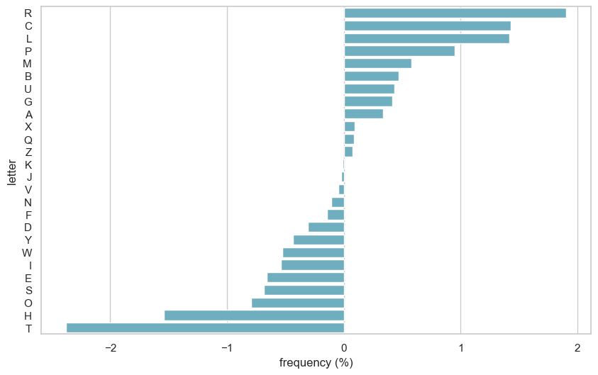

```python
plot_letter_frequency(eng_freq.frequency - actual_frequency)
```

Findings:

Conclusion: It seems that the letter frequency might be "close enough" to english. But we might be fooling ourselves, trying to see things that are not there.

Let's do a quick check using Chi2.

$H_0$ = The observed letter frequencies in the comments column **do not significantly differ** from the expected frequencies of letters in the English language.

$H_1$ = The observed letter frequencies in the comments column **significantly differ** from the expected frequencies of letters in the English language.

Significance $\alpha = 0.05$

```python
pd.DataFrame(
    {
        "expected": eng_freq.frequency,
        "actual": actual_frequency,
        "diff": eng_freq.frequency - actual_frequency,
        "diff^2": (eng_freq.frequency - actual_frequency) ** 2,
        "chi2_term": ((eng_freq.frequency - actual_frequency) ** 2) / eng_freq.frequency,
    }
)["chi2_term"].sum()
```

```
0.04232933448492569
```

```python
chi2, p_val = chisquare(actual_frequency, f_exp=eng_freq.frequency)

print(f"Chi2 statistic: {chi2}")
print(f"P-value: {p_val}")
```

```
Chi2 statistic: 0.04232933448492569
P-value: 1.0
```

This does not prove that all/any of the comments are in English, but it allow us to not have to worry about this, for now.. (particularly useful when we get to embeddings and choosing a dictionary/word list)

## Word Counts

Let's also count words to get a magnitude of what our corpus looks like.

```python
vectorizer = CountVectorizer(analyzer="word")

texts = splits["hp_X"].comment_text

X_transformed = vectorizer.fit_transform(texts)

X_transformed = X_transformed.toarray()
```

```python
X_transformed
```

```
array([[0, 0, 0, ..., 0, 0, 0],
       [0, 0, 0, ..., 0, 0, 0],
       [0, 0, 0, ..., 0, 0, 0],
       ...,
       [0, 0, 0, ..., 0, 0, 0],
       [0, 0, 0, ..., 0, 0, 0],
       [0, 0, 0, ..., 0, 0, 0]])
```

```python
print(np.sum(X_transformed), "words")
```

```
1031901 words
```

# Training a model to classify toxic comments

```python
splits = dataset_split()
```

```
Loading from cache [./cached/df_dict/dataset_split.h5.gitignored]
```

```python
features = ["comment_text"]
labels = ["toxic", "severe_toxic", "obscene", "threat", "insult", "identity_hate"]
```

```python
def store_cached_dataset_to_csv():
    splits = dataset_split()

    for s in ["train", "hp", "val", "test"]:
        md(f"**storing {s} split**")
        X = splits[f"{s}_X"]
        y = splits[f"{s}_y"]
        xs = X.shape
        ys = y.shape
        after = X.join(y)
        aftershape = after.shape
        assert aftershape[0] == xs[0]
        assert aftershape[0] == ys[0]
        assert aftershape[1] == xs[1] + ys[1]
        print(s, aftershape)

        after = after[features + labels]
        after["labels"] = after[labels].values.tolist()
        after = after.drop(columns=labels)
        after.to_csv(f"dataset/splits/{s}.csv", index=False)  # =["id"])
        print(after.columns)
        print(after.iloc[5:10])


store_cached_dataset_to_csv()
```

```
Loading from cache [./cached/df_dict/dataset_split.h5.gitignored]
```

**storing train split**

```
train (111700, 8)
Index(['comment_text', 'labels'], dtype='object')
                                             comment_text              labels
143038  "\n\n Blocked  \nHi, I blocked you for 24 hour...  [0, 0, 0, 0, 0, 0]
101451  Shelly, A. \n\nNext thing we know you'll be ta...  [0, 0, 0, 0, 0, 0]
58349   Georgi Kinkladze \n\nI took the article to FAC...  [0, 0, 0, 0, 0, 0]
63154   That IS APPROPRIATE TALK you fucking dipshit. ...  [1, 1, 1, 1, 1, 0]
83999   These is indeed no such conflict as David imag...  [0, 0, 0, 0, 0, 0]
```

**storing hp split**

```
hp (15957, 8)
Index(['comment_text', 'labels'], dtype='object')
                                             comment_text              labels
136963  "Please do not replace Wikipedia pages with bl...  [0, 0, 0, 0, 0, 0]
10118   facts!\nThe Soviets faked it up as very erly a...  [0, 0, 0, 0, 0, 0]
105263  BABS \n\nHi Betacommand:  We're noticing that ...  [0, 0, 0, 0, 0, 0]
109078  Stick it up your arse as far as it will go, th...  [1, 0, 1, 0, 0, 0]
33873   Even IF Egypt has a vcivil war that would be a...  [0, 0, 0, 0, 0, 0]
```

**storing val split**

```
val (15957, 8)
Index(['comment_text', 'labels'], dtype='object')
                                            comment_text              labels
66866  . I've gone with the coordinates given at this...  [0, 0, 0, 0, 0, 0]
15513  Dab, if thast what it takes to resolve the iss...  [0, 0, 0, 0, 0, 0]
28674  "\n\nNo Rodhullandemu, as I've proven in my po...  [1, 0, 0, 0, 0, 0]
48832  Expanded a bit. Will see if I can find out a b...  [0, 0, 0, 0, 0, 0]
93777  "If trivial information is deemed relevant bec...  [0, 0, 0, 0, 0, 0]
```

**storing test split**

```
test (15957, 8)
Index(['comment_text', 'labels'], dtype='object')
                                             comment_text              labels
150905                           .98.62]] 20:27, 8 August  [0, 0, 0, 0, 0, 0]
10399   Live stream \n\nFor a short time this live str...  [0, 0, 0, 0, 0, 0]
17703   FUCKAN STOP CHANGON IT OR I AM TWIST OFF YOURE...  [1, 1, 1, 0, 1, 0]
63289   "\n\n Chronology of first translation (by nati...  [0, 0, 0, 0, 0, 0]
101228  BS DEF \n\n nonstandard spelling for speech to...  [0, 0, 0, 0, 0, 0]
```

```python
def load_comments_dataset() -> DatasetDict:
    dataset = load_dataset(
        "csv",
        data_files={
            "train": "dataset/splits/train.csv",
            "hp": "dataset/splits/hp.csv",
            "val": "dataset/splits/val.csv",
            "test": "dataset/splits/test.csv",
        },
    )

    for split in dataset.keys():
        dataset[split] = dataset[split].map(
            lambda e: {"labels": [float(x) for x in e["labels"][1:-1].split(", ")]}
        )

    return dataset
```

```python
load_comments_dataset()
```

```
Generating train split: 0 examples [00:00, ? examples/s]
```

```
Generating hp split: 0 examples [00:00, ? examples/s]
```

```
Generating val split: 0 examples [00:00, ? examples/s]
```

```
Generating test split: 0 examples [00:00, ? examples/s]
```

```
DatasetDict({
    train: Dataset({
        features: ['comment_text', 'labels'],
        num_rows: 111700
    })
    hp: Dataset({
        features: ['comment_text', 'labels'],
        num_rows: 15957
    })
    val: Dataset({
        features: ['comment_text', 'labels'],
        num_rows: 15957
    })
    test: Dataset({
        features: ['comment_text', 'labels'],
        num_rows: 15957
    })
})
```

```python
raw_datasets = load_comments_dataset()
checkpoint = "bert-base-cased"
tokenizer = AutoTokenizer.from_pretrained(checkpoint)
```

```python
def tokenize_comment(examples):
    return tokenizer(
        examples["comment_text"],
        truncation=True,
    )


tokenized_datasets = raw_datasets.map(
    tokenize_comment,
    batched=True,
    batch_size=1000,
)
data_collator = DataCollatorWithPadding(tokenizer)
```

```python
tokenized_datasets
```

```
DatasetDict({
    train: Dataset({
        features: ['comment_text', 'labels', 'input_ids', 'token_type_ids', 'attention_mask'],
        num_rows: 111700
    })
    hp: Dataset({
        features: ['comment_text', 'labels', 'input_ids', 'token_type_ids', 'attention_mask'],
        num_rows: 15957
    })
    val: Dataset({
        features: ['comment_text', 'labels', 'input_ids', 'token_type_ids', 'attention_mask'],
        num_rows: 15957
    })
    test: Dataset({
        features: ['comment_text', 'labels', 'input_ids', 'token_type_ids', 'attention_mask'],
        num_rows: 15957
    })
})
```

We have tokenized each sentence individually

```python
tokenized_datasets["train"]["input_ids"][0]
```

```
[101, 8790, 190, 1197, 1132, 1714, 1106, 5194, 5324, 1105, 4068, 102]
```

```python
tokenized_datasets["train"]["input_ids"][2]
```

```
[101,
 113,
 11984,
 131,
 2140,
 117,
 146,
 2014,
 1142,
 1106,
 1380,
 171,
 21077,
 114,
 102]
```

Things look as expected:

- A sequence of tokens
- Starting with 101 (CLS) and ending with 102 (SEP)
- They have different lengths (and no padding) because padding will be done later by the `DataCollatorWithPadding()`

```python
checkpoint
```

```
'bert-base-cased'
```

```python
model = AutoModelForSequenceClassification.from_pretrained(
    checkpoint,
    num_labels=6,
    problem_type="multi_label_classification",
)
```

```
Some weights of BertForSequenceClassification were not initialized from the model checkpoint at bert-base-cased and are newly initialized: ['classifier.weight', 'classifier.bias']
You should probably TRAIN this model on a down-stream task to be able to use it for predictions and inference.
```

We get the correct warning, indicating that the model has been customized for a downstream task (6 output labels) and those have not been loaded/trained).

This entire project is about training this downstream model.

## Training our model to detect toxic comments

In this section, we will train the downstream classifier so it is able to perform well in our task of interest.

Before doing this, we will want to optimize the configuration so that training is both effective and efficient.

This will require not exceeding the max GPU memory.

### Configuring our training so it fits our resources

We tried various combinations of configurations but found that enabling FP16 contributes immensely to speeding up training.

Let this table compare just a couple of configurations done on the exact same PC

| FP16 | Training Batch Size | GPU Memory Usage | Training time | Chosen configuration |
| --- | --- | --- | --- | --- |
| False | 8 | 10GB | 5hr |  |
| True | 12 | 8GB | 3hr | ⭐ |

Just from enabling FP16, *which does not sacrifice model performance*, and only adjusts float-precision when needed, we can see:

- it allows for 50% larger batch size, improving training
- while keeping a 20% smaller memory footprint
- and almost 2x faster end to end training time

A quick "back of the envelope" calculation ${10 \over 8} * {5 \over 3} = 2.1$ factor of boost in performance

These values were just tweaked and adjusted on the fly. The main goal was to make sure that the training could complete without exceeding the GPU memory.

Since the entire training would take hours and it would complete overnight, I wanted to be conservative with the tweaking (taking 1hr longer is fine, but crashing at 3am and not completing would mean having to spend 5h the next morning retraining). This is why the memory was adjusted to be around 8GK instead of trying to max out the 12GB that the card has.

```python
training_args = TrainingArguments(
    "test-trainer",
    #
    # trying not to max my GPU memory (this uses ~70% of gpu memory)
    per_device_train_batch_size=12,
    #
    # dont want it to crash while im sleeping!
    per_device_eval_batch_size=6,
    #
    num_train_epochs=5,
    learning_rate=2e-5,
    weight_decay=0.01,
    #
    # let's sacrifice a bit of float precision for maybe lighter model?
    fp16=True,
)

trainer = Trainer(
    model,
    training_args,
    train_dataset=tokenized_datasets["train"],
    eval_dataset=tokenized_datasets["val"],
    data_collator=data_collator,
    tokenizer=tokenizer,
)
```

```python
raise ValueError("")
```

[output not shown]

```python
if run_entire_notebook("model_training"):
    trainer.train()
```

[46545/46545 3:03:58, Epoch 5/5]

| Step | Training Loss |
| --- | --- |
| 500 | 0.050700 |
| 1000 | 0.054400 |
| 1500 | 0.053300 |
| 2000 | 0.047800 |
| 2500 | 0.051100 |
| 3000 | 0.045400 |
| 3500 | 0.044500 |
| 4000 | 0.046900 |
| 4500 | 0.042700 |
| 5000 | 0.046000 |
| 5500 | 0.047400 |
| 6000 | 0.040900 |
| 6500 | 0.043700 |
| 7000 | 0.045300 |
| 7500 | 0.041900 |
| 8000 | 0.041400 |
| 8500 | 0.042700 |
| 9000 | 0.044100 |
| 9500 | 0.038000 |
| 10000 | 0.032700 |
| 10500 | 0.032600 |
| 11000 | 0.034200 |
| 11500 | 0.034600 |
| 12000 | 0.034100 |
| 12500 | 0.033900 |
| 13000 | 0.033100 |
| 13500 | 0.034600 |
| 14000 | 0.032400 |
| 14500 | 0.032000 |
| 15000 | 0.030300 |

[output cut: 63 more lines]

```
Checkpoint destination directory test-trainer/checkpoint-500 already exists and is non-empty.Saving will proceed but saved results may be invalid.
```

```
TrainOutput(global_step=46545, training_loss=0.025472583039156, metrics={'train_runtime': 11038.7245, 'train_samples_per_second': 50.595, 'train_steps_per_second': 4.217, 'total_flos': 9.332705466672912e+16, 'train_loss': 0.025472583039156, 'epoch': 5.0})
```

A quick check at our GPU Usage shows that it's well below its limit of 12GB, so I can go to bed and get a good night's sleep without worrying about this accidentally crashing through the roof if it were to accidentally find a randomly "chunky" batch.

```
(py39_lab4) edu@desk:~$ nvidia-smi
Tue Jan  9 02:07:39 2024
+---------------------------------------------------------------------------------------+
| NVIDIA-SMI 535.129.03             Driver Version: 535.129.03   CUDA Version: 12.2     |
|-----------------------------------------+----------------------+----------------------+
| GPU  Name                 Persistence-M | Bus-Id        Disp.A | Volatile Uncorr. ECC |
| Fan  Temp   Perf          Pwr:Usage/Cap |         Memory-Usage | GPU-Util  Compute M. |
|                                         |                      |               MIG M. |
|=========================================+======================+======================|
|   0  NVIDIA GeForce RTX 3060        Off | 00000000:01:00.0  On |                  N/A |
| 43%   64C    P2             129W / 170W |   9015MiB / 12288MiB |     97%      Default |
|                                         |                      |                  N/A |
+-----------------------------------------+----------------------+----------------------+

+---------------------------------------------------------------------------------------+
| Processes:                                                                            |
|  GPU   GI   CI        PID   Type   Process name                            GPU Memory |
|        ID   ID                                                             Usage      |
|=======================================================================================|
|    0   N/A  N/A      1277      G   /usr/lib/xorg/Xorg                          292MiB |
|    0   N/A  N/A      1930      G   cinnamon                                     69MiB |
|    0   N/A  N/A      2578      G   /usr/lib/firefox/firefox                    191MiB |
|    0   N/A  N/A     36566      G   nvidia-settings                               2MiB |
|    0   N/A  N/A     88092      C   ...anaconda3/envs/py39_lab4/bin/python     8442MiB |
+---------------------------------------------------------------------------------------+
(py39_lab4) edu@desk:~$
```

[figure not shown]

There seems to be ample headroom before the GPU thermally-throttles, and it doesn't seem to be increasing.

I think I can go to bed without worrying about this crashing or slowing down. I expect this to take 3h as predicted.

[figure not shown]

The next morning ☀️

The training took exactly as expected (just over 3h), and the PC hasn't crashed!

Nice!

### Save the model to disk

```python
if run_entire_notebook():
    # We only want to do this when we run the entire notebook,
    # to avoid accidentally overwriting the file
    torch.save(model, "models/trained_model_full.pt")
```

```
skipping optional operation
```

```python
loaded_model = torch.load("models/trained_model_full.pt")
```

Let's inspect the loaded model to make sure it has the shape we expect:

```python
loaded_model.config
```

```
BertConfig {
  "_name_or_path": "bert-base-cased",
  "architectures": [
    "BertForSequenceClassification"
  ],
  "attention_probs_dropout_prob": 0.1,
  "classifier_dropout": null,
  "gradient_checkpointing": false,
  "hidden_act": "gelu",
  "hidden_dropout_prob": 0.1,
  "hidden_size": 768,
  "id2label": {
    "0": "LABEL_0",
    "1": "LABEL_1",
    "2": "LABEL_2",
    "3": "LABEL_3",
    "4": "LABEL_4",
    "5": "LABEL_5"
  },
  "initializer_range": 0.02,
  "intermediate_size": 3072,
  "label2id": {
    "LABEL_0": 0,
    "LABEL_1": 1,
    "LABEL_2": 2,
    "LABEL_3": 3,
    "LABEL_4": 4,
    "LABEL_5": 5
  },
  "layer_norm_eps": 1e-12,
  "max_position_embeddings": 512,
  "model_type": "bert",
  "num_attention_heads": 12,
  "num_hidden_layers": 12,
  "pad_token_id": 0,
  "position_embedding_type": "absolute",
  "problem_type": "multi_label_classification",
  "torch_dtype": "float32",
  "transformers_version": "4.36.2",
  "type_vocab_size": 2,
  "use_cache": true,
  "vocab_size": 28996
}
```

We noticed that we forgot a minor issue.. we didn't configure the label2id and the id2label...

But given that it takes 3h to train, I think we can live with this imperfection.

Everything else seems to indicate that this is the model we created and that we can successfully load it from disk.

Let's configure our trainer to use the model we stored in the past, for the rest of the notebook. This will make future runs of this notebook faster and not make us spend 3h every time.

```python
if not run_entire_notebook():
    print("reconfiguring trainer to use loaded model from disk")
    trainer = Trainer(
        loaded_model,
        training_args,
        train_dataset=tokenized_datasets["train"],
        eval_dataset=tokenized_datasets["val"],
        data_collator=data_collator,
        tokenizer=tokenizer,
    )
```

```
skipping optional operation
reconfiguring trainer to use loaded model from disk
```

```python
predictions = trainer.predict(tokenized_datasets["val"])
print(predictions.predictions.shape, predictions.label_ids.shape)
```

```
You're using a BertTokenizerFast tokenizer. Please note that with a fast tokenizer, using the `__call__` method is faster than using a method to encode the text followed by a call to the `pad` method to get a padded encoding.
```

```
(15957, 6) (15957, 6)
```

```python
sigmoid_outputs = torch.sigmoid(torch.from_numpy(predictions.predictions))

threshold = 0.5
preds = (sigmoid_outputs > threshold).int()

# Since we don't care about where the errors happen, and we want to count them all equally, we can flatten the nested arrays and then do the comparison
flat_preds = preds.flatten()
flat_labels = predictions.label_ids.flatten()
```

```python
acc = load_metric("accuracy", trust_remote_code=True)
prec = load_metric("precision", trust_remote_code=True)
recall = load_metric("recall", trust_remote_code=True)
f1 = load_metric("f1", trust_remote_code=True)
```

```python
acc.compute(predictions=flat_preds, references=flat_labels)
```

```
{'accuracy': 0.9841762236009275}
```

```python
prec.compute(predictions=flat_preds, references=flat_labels)
```

```
{'precision': 0.7880143112701252}
```

```python
recall.compute(predictions=flat_preds, references=flat_labels)
```

```
{'recall': 0.7667536988685814}
```

```python
f1.compute(predictions=flat_preds, references=flat_labels)
```

```
{'f1': 0.7772386413762682}
```

```python
true_labels = np.array(tokenized_datasets["val"]["labels"])
```

```python
true_labels[:10]
```

```
array([[0., 0., 0., 0., 0., 0.],
       [0., 0., 0., 0., 0., 0.],
       [0., 0., 0., 0., 0., 0.],
       [0., 0., 0., 0., 0., 0.],
       [0., 0., 0., 0., 0., 0.],
       [0., 0., 0., 0., 0., 0.],
       [0., 0., 0., 0., 0., 0.],
       [1., 0., 0., 0., 0., 0.],
       [0., 0., 0., 0., 0., 0.],
       [0., 0., 0., 0., 0., 0.]])
```

```python
sigmoid_outputs = sigmoid_outputs.detach().cpu().numpy()
```

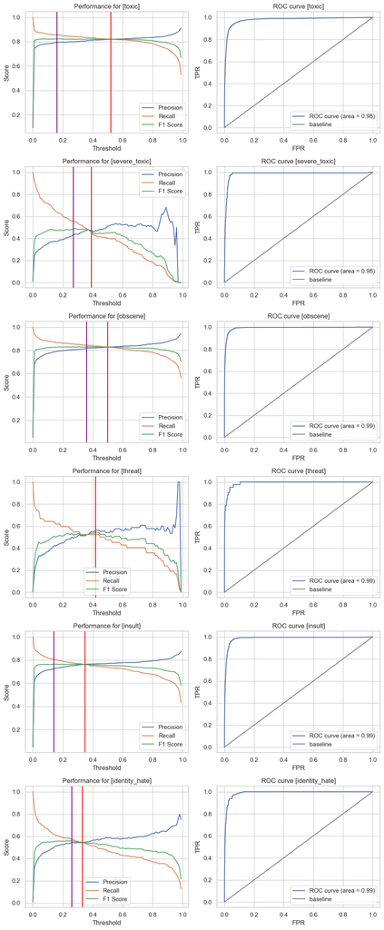

```python
f, ax = plt.subplots(6, 2, figsize=(10, 24))

thresholds = np.arange(0, 1, 0.01)
num_labels = 6

optimal_thresholds = [0.52, 0.39, 0.5, 0.42, 0.35, 0.33]

for i in range(num_labels):
    row = i
    col = 0
    precisions, recalls, f1_scores = [], [], []
    for threshold in thresholds:
        preds = (sigmoid_outputs[:, i] > threshold).astype(int)
        precisions.append(precision_score(true_labels[:, i], preds))
        recalls.append(recall_score(true_labels[:, i], preds))
        f1_scores.append(f1_score(true_labels[:, i], preds))

    ax[row, col].plot(thresholds, precisions, label="Precision")
    ax[row, col].plot(thresholds, recalls, label="Recall")
    ax[row, col].plot(thresholds, f1_scores, label="F1 Score")

    fpr, tpr, _ = roc_curve(true_labels[:, i], sigmoid_outputs[:, i])
    roc_auc = auc(fpr, tpr)

    ax[row, col].set_xlabel("Threshold")
    ax[row, col].set_ylabel("Score")
    ax[row, col].set_title(f"Performance for [{labels[i]}]")
    auto_threshold = np.array(f1_scores).argmax() / 100
    ax[row, col].axvline(x=auto_threshold, color="purple")
    ax[row, col].axvline(x=optimal_thresholds[i], color="red")
    ax[row, 0].grid(True)
    ax[row, 0].legend()

    ax[row, 1].plot(fpr, tpr, label="ROC curve (area = %0.2f)" % roc_auc)
    ax[row, 1].plot([0, 1], [0, 1], label="baseline", color="grey")
    ax[row, 1].set_xlabel("FPR")
    ax[row, 1].set_ylabel("TPR")
    ax[row, 1].set_title(f"ROC curve [{labels[i]}]")
    ax[row, 1].legend()
    ax[row, 1].grid(True)


plt.tight_layout()
plt.show()
```

The high score on the ROC curve is likely caused by the major imbalance in the dataset (most comments are "non-toxic"), so the chart to correctly understand how the model performs are the ones on the left column (precision, recall, f1)

### Performance Analysis

It seems that the model is fairly good at making predictions, but that it does suffer in cases where there is not enough data.

Just from the charts, we can easily identify the rare classes:

- threat
- identity_hate
- and severe_toxic

We can see it from the lower performance, and we can also see it in the jagged line edges. The classes with more data show smoother lines.

We can also see that their threshold should be adjusted, in order to provide the best possible performance.

We have adjusted and plotted these optimal thresholds on top of the charts to visualize them better.

The red line shows the "manually configured" threshold, the purple line shows the "max f1 score".

We could look at other metrics (`sklearn.metrics.precision_recall_fscore_support()` comes to mind) that would allow us to customize the weight for accuracy and recall so it's not 50/50%. This will largely depend on the business needs (What is the cost for incorrectly labeling a comment as toxic? what is the cost for failing to identify those?) etc...

But for now, the out-of-the-box f1score seems good enough.

### Tuning thresholds for better performance

Let's do the same, after adjusting the thresholds to the ones selected manually

```python
predictions = trainer.predict(tokenized_datasets["val"])
print(predictions.predictions.shape, predictions.label_ids.shape)
```

```
(15957, 6) (15957, 6)
```

```python
acc = load_metric("accuracy", trust_remote_code=True)
prec = load_metric("precision", trust_remote_code=True)
recall = load_metric("recall", trust_remote_code=True)
f1 = load_metric("f1", trust_remote_code=True)
```

```python
sigmoid_outputs = torch.sigmoid(torch.from_numpy(predictions.predictions))

new_thresholds = torch.tensor(optimal_thresholds)
preds = (sigmoid_outputs > new_thresholds).int()

flat_preds = preds.flatten()
flat_labels = predictions.label_ids.flatten()
```

```python
acc.compute(predictions=flat_preds, references=flat_labels)
```

```
{'accuracy': 0.9840822209688538}
```

```python
prec.compute(predictions=flat_preds, references=flat_labels)
```

```
{'precision': 0.7792622712750509}
```

```python
recall.compute(predictions=flat_preds, references=flat_labels)
```

```
{'recall': 0.7783579924572092}
```

```python
f1.compute(predictions=flat_preds, references=flat_labels)
```

```
{'f1': 0.7788098693759071}
```

The old scores were

> - {'accuracy': 0.9841762236009275}
> - {'precision': 0.7880143112701252}
> - {'recall': 0.7667536988685814}
> - {'f1': 0.7772386413762682}

As expected, given the small tweaks, the scores vary a bit, but not a lot.

**The overall score f1 does improve a bit**, which is the one we were trying to tweak and boost.

If we wanted to boost any of the other scores (recall, etc.. ) we could easily select other thresholds and apply them.

```python
sigmoid_outputs = sigmoid_outputs.detach().cpu().numpy()
```

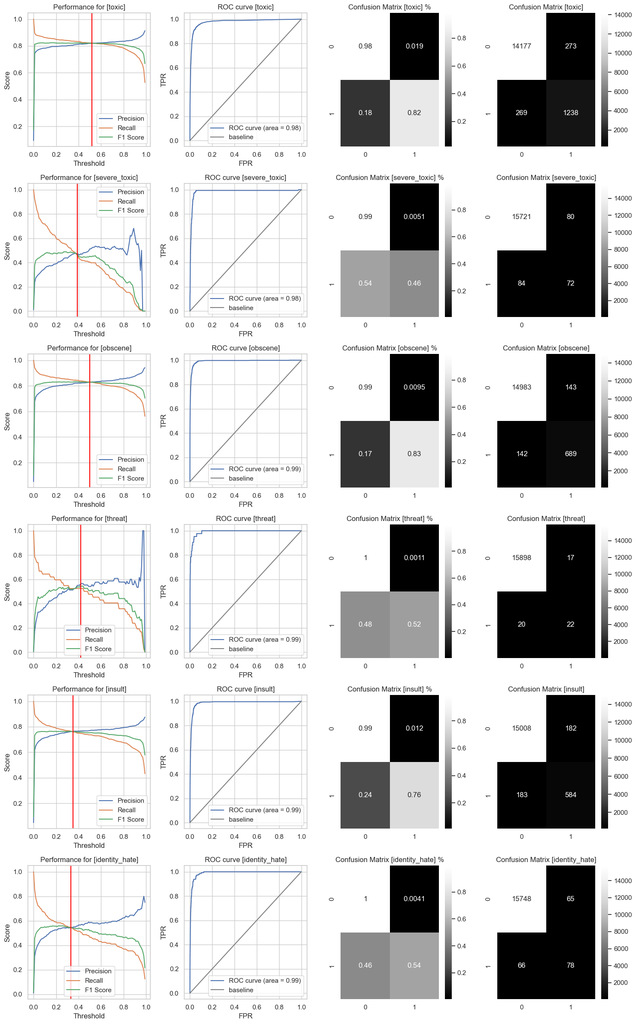

```python
import seaborn as sns
from sklearn.metrics import confusion_matrix

f, ax = plt.subplots(6, 4, figsize=(15, 24))

thresholds = np.arange(0, 1, 0.01)
num_labels = 6

optimal_thresholds = [0.52, 0.39, 0.5, 0.42, 0.35, 0.33]

for i in range(num_labels):
    row = i
    col = 0
    precisions, recalls, f1_scores = [], [], []
    for threshold in thresholds:
        preds = (sigmoid_outputs[:, i] > threshold).astype(int)
        precisions.append(precision_score(true_labels[:, i], preds))
        recalls.append(recall_score(true_labels[:, i], preds))
        f1_scores.append(f1_score(true_labels[:, i], preds))

    ax[row, col].plot(thresholds, precisions, label="Precision")
    ax[row, col].plot(thresholds, recalls, label="Recall")
    ax[row, col].plot(thresholds, f1_scores, label="F1 Score")

    fpr, tpr, _ = roc_curve(true_labels[:, i], sigmoid_outputs[:, i])
    roc_auc = auc(fpr, tpr)

    ax[row, col].set_xlabel("Threshold")
    ax[row, col].set_ylabel("Score")
    ax[row, col].set_title(f"Performance for [{labels[i]}]")
    auto_threshold = np.array(f1_scores).argmax() / 100
    ax[row, col].axvline(x=optimal_thresholds[i], color="red")
    ax[row, col].grid(True)
    ax[row, col].legend()

    ax[row, 1].plot(fpr, tpr, label="ROC curve (area = %0.2f)" % roc_auc)
    ax[row, 1].plot([0, 1], [0, 1], label="baseline", color="grey")
    ax[row, 1].set_xlabel("FPR")
    ax[row, 1].set_ylabel("TPR")
    ax[row, 1].set_title(f"ROC curve [{labels[i]}]")
    ax[row, 1].legend()
    ax[row, 1].grid(True)

    optimal_preds = (sigmoid_outputs[:, i] > optimal_thresholds[i]).astype(int)
    cm = confusion_matrix(true_labels[:, i], optimal_preds, normalize="true")
    sns.heatmap(cm, annot=True, ax=ax[row, 2], cmap="Greys_r")
    ax[row, 2].set_title(f"Confusion Matrix [{labels[i]}] %")

    optimal_preds = (sigmoid_outputs[:, i] > optimal_thresholds[i]).astype(int)
    cm = confusion_matrix(true_labels[:, i], optimal_preds)
    sns.heatmap(cm, annot=True, ax=ax[row, 3], fmt="d", cmap=ListedColormap(["white"]))
    ax[row, 3].set_title(f"Confusion Matrix [{labels[i]}]")

plt.tight_layout()
plt.show()
```

## Test our model on the test data split

Let's check how our model performs on unseen data.

```python
predictions = trainer.predict(tokenized_datasets["test"])
print(predictions.predictions.shape, predictions.label_ids.shape)
```

```
(15957, 6) (15957, 6)
```

During some of the debugging I was getting weird behaviour in the test split so I had to debug and investigate a bit. I'm leaving this just to showcase some of the interesting spellings that seem to be intentional to try to fool a simple classifier.

Some of these words are gloriously mispelled `I AM TWIST OFF YOURE LITTOL PEE-WEES, FUCKAN IDEOT`, but it's **comforting to see how the model is able to correctly detect** that this comment (3rd comment below) is still correctly identified as 4 different types of toxic.

```python
for r in (
    pd.DataFrame(tokenized_datasets["test"])[["comment_text", "labels"]]
    .iloc[5:15]
    .iterrows()
):
    print(">>>>>>", r[1].comment_text)
```

```
>>>>>> .98.62]] 20:27, 8 August
>>>>>> Live stream

For a short time this live stream very good worked:

192.5.109.51/ostn_usa.asx

It´s not pay tv  and it´s not illegal , but the access is now blocked. Can someone get this to work again?
>>>>>> FUCKAN STOP CHANGON IT OR I AM TWIST OFF YOURE LITTOL PEE-WEES AND YOURE FUCKON MONKEY

FUCKAN IDEOT my name am JOSSEL MUBEDEON AND I DONE FUCKON MAKE THINGS BETTOR

I FIXES THINGS

undarstand
>>>>>> "

 Chronology of first translation (by nation) in national newspapers

I have added to sections (which might be suitable as subsections of a yet to be determined section),
""Date of the first translation (by nation) in national newspapers""
""Translations published on websites of national newspapers""

The sections are notable and encyclopedic. (When was the last time a poem was translated and printed in national newspapers in more than 4 countries?)

That websites print poems, is possibly less notable then when national newspapers in different countries prints them. (There seems to be somewhat of a threshold regarding printing poems in newspapers, on pages allocated to literature reviews etc—the Norwegian newspaper Aftenposten is one example of …

As the first section is improved, then it might indicate the chronology of when the very first national newspapers (in various nations) printed translations of the poem. (I would not be suprised if my Nordic country was ""the last Nordic country to print the poem""—not that anyone necessarily could …
>>>>>> BS DEF

 nonstandard spelling for speech to draw attention to an ironically standard pronunciation. CMON..HUGETSDAD:(
>>>>>> Sorry coffee break, and?126.12.157.168
>>>>>> ": I did not write that line.  All I did was link the video. I wouldn't know Dvorak from Grieg.  I added the Jimmy Durante video - my bad.  I did not realize they were verbotten. The clip is NOT from the movie, however.  It is from another.  and lastly - I've been told so many time to sign my…

"
>>>>>> Is it possible to add this information in the main artile (for common readers).
>>>>>> January 2015 (UTC)
Would any of these be useable?  They are in the public domain, but I'm not sure whether FOP might still apply.   14:07, 14
>>>>>> "

 File:Kid_Pix_1.0_About.png listed for deletion
A file that you uploaded or altered, File:Kid_Pix_1.0_About.png, has been listed at Wikipedia:Files for deletion. Please see the discussion to see why this is (you may have to search for the title of the image to find its entry), if you are interested in it not being deleted. Thank you.   "
```

```python
tokenized_datasets["test"]["comment_text"][5:15]
```

```
['.98.62]] 20:27, 8 August',
 'Live stream \n\nFor a short time this live stream very good worked:\n\n192.5.109.51/ostn_usa.asx\n\nIt´s not pay tv  and it´s not illegal , but the access is now blocked. Can someone get this to work again?',
 'FUCKAN STOP CHANGON IT OR I AM TWIST OFF YOURE LITTOL PEE-WEES AND YOURE FUCKON MONKEY\n\nFUCKAN IDEOT my name am JOSSEL MUBEDEON AND I DONE FUCKON MAKE THINGS BETTOR\n\nI FIXES THINGS\n\nundarstand',
 '"\n\n Chronology of first translation (by nation) in national newspapers \n\nI have added to sections (which might be suitable as subsections of a yet to be determined section), \n""Date of the first translation (by nation) in national newspapers""\n""Translations published on websites of national…
 'BS DEF \n\n nonstandard spelling for speech to draw attention to an ironically standard pronunciation. CMON..HUGETSDAD:(',
 'Sorry coffee break, and?126.12.157.168',
 '": I did not write that line.  All I did was link the video. I wouldn\'t know Dvorak from Grieg.  I added the Jimmy Durante video - my bad.  I did not realize they were verbotten. The clip is NOT from the movie, however.  It is from another.  and lastly - I\'ve been told so many time to sign my po…
 'Is it possible to add this information in the main artile (for common readers).',
 "January 2015 (UTC)\nWould any of these be useable?  They are in the public domain, but I'm not sure whether FOP might still apply.   14:07, 14",
 '"\n\n File:Kid_Pix_1.0_About.png listed for deletion \nA file that you uploaded or altered, File:Kid_Pix_1.0_About.png, has been listed at Wikipedia:Files for deletion. Please see the discussion to see why this is (you may have to search for the title of the image to find its entry), if you are in…
```

```python
print(np.round(predictions.predictions[5:15]))
```

```
[[ -9. -10.  -9. -10.  -9. -10.]
 [ -9. -10.  -9. -10.  -9. -10.]
 [  7.   0.   7.  -2.   5.  -5.]
 [ -9. -10.  -9. -10.  -9. -10.]
 [ -9. -10.  -9. -10.  -9. -10.]
 [ -9. -10.  -9. -10.  -9. -10.]
 [ -9. -10.  -9. -10.  -9. -10.]
 [ -9. -10.  -9. -10.  -9. -10.]
 [ -9. -10.  -9. -10.  -9. -10.]
 [ -9. -10.  -9. -10.  -9. -10.]]
```

```python
print(predictions.label_ids[5:15])
```

```
[[0. 0. 0. 0. 0. 0.]
 [0. 0. 0. 0. 0. 0.]
 [1. 1. 1. 0. 1. 0.]
 [0. 0. 0. 0. 0. 0.]
 [0. 0. 0. 0. 0. 0.]
 [0. 0. 0. 0. 0. 0.]
 [0. 0. 0. 0. 0. 0.]
 [0. 0. 0. 0. 0. 0.]
 [0. 0. 0. 0. 0. 0.]
 [0. 0. 0. 0. 0. 0.]]
```

```python
acc = load_metric("accuracy", trust_remote_code=True)
prec = load_metric("precision", trust_remote_code=True)
recall = load_metric("recall", trust_remote_code=True)
f1 = load_metric("f1", trust_remote_code=True)
```

```python
new_thresholds
```

```
tensor([0.5200, 0.3900, 0.5000, 0.4200, 0.3500, 0.3300])
```

```python
sigmoid_outputs = torch.sigmoid(torch.from_numpy(predictions.predictions))

new_thresholds = torch.tensor(optimal_thresholds)
preds = (sigmoid_outputs > new_thresholds).int()

flat_preds = preds.flatten()
flat_labels = predictions.label_ids.flatten()
```

```python
acc.compute(predictions=flat_preds, references=flat_labels)
```

```
{'accuracy': 0.9836748762298678}
```

```python
prec.compute(predictions=flat_preds, references=flat_labels)
```

```
{'precision': 0.7851193781232648}
```

```python
recall.compute(predictions=flat_preds, references=flat_labels)
```

```
{'recall': 0.781863422726016}
```

```python
f1.compute(predictions=flat_preds, references=flat_labels)
```

```
{'f1': 0.7834880177309876}
```

```python
true_labels = np.array(tokenized_datasets["test"]["labels"])
```

The old scores were

> - {'accuracy': 0.9841762236009275}
> - {'precision': 0.7880143112701252}
> - {'recall': 0.7667536988685814}
> - {'f1': 0.7772386413762682}

As expected, given the small tweaks, the scores vary a bit, but not a lot.

**The overall score f1 does improve a bit**, which is the one we were trying to tweak and boost.

If we wanted to boost any of the other scores (recall, etc.. ) we could easily select other thresholds and apply them.

```python
sigmoid_outputs = sigmoid_outputs.detach().cpu().numpy()
```

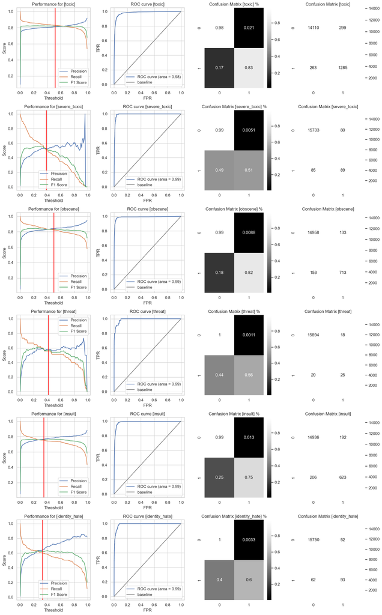

```python
import seaborn as sns
from sklearn.metrics import confusion_matrix

f, ax = plt.subplots(6, 4, figsize=(15, 24))

thresholds = np.arange(0, 1, 0.01)
num_labels = 6

for i in range(num_labels):
    row = i
    col = 0
    precisions, recalls, f1_scores = [], [], []
    for threshold in thresholds:
        preds = (sigmoid_outputs[:, i] > threshold).astype(int)
        precisions.append(precision_score(true_labels[:, i], preds))
        recalls.append(recall_score(true_labels[:, i], preds))
        f1_scores.append(f1_score(true_labels[:, i], preds))

    ax[row, col].plot(thresholds, precisions, label="Precision")
    ax[row, col].plot(thresholds, recalls, label="Recall")
    ax[row, col].plot(thresholds, f1_scores, label="F1 Score")

    fpr, tpr, _ = roc_curve(true_labels[:, i], sigmoid_outputs[:, i])
    roc_auc = auc(fpr, tpr)

    ax[row, col].set_xlabel("Threshold")
    ax[row, col].set_ylabel("Score")
    ax[row, col].set_title(f"Performance for [{labels[i]}]")
    auto_threshold = np.array(f1_scores).argmax() / 100
    ax[row, col].axvline(x=optimal_thresholds[i], color="red")
    ax[row, col].grid(True)
    ax[row, col].legend()

    ax[row, 1].plot(fpr, tpr, label="ROC curve (area = %0.2f)" % roc_auc)
    ax[row, 1].plot([0, 1], [0, 1], label="baseline", color="grey")
    ax[row, 1].set_xlabel("FPR")
    ax[row, 1].set_ylabel("TPR")
    ax[row, 1].set_title(f"ROC curve [{labels[i]}]")
    ax[row, 1].legend()
    ax[row, 1].grid(True)

    # Add confusion matrix in the 3rd column
    optimal_preds = (sigmoid_outputs[:, i] > optimal_thresholds[i]).astype(int)
    cm = confusion_matrix(true_labels[:, i], optimal_preds, normalize="true")
    sns.heatmap(cm, annot=True, ax=ax[row, 2], cmap="Greys_r")
    ax[row, 2].set_title(f"Confusion Matrix [{labels[i]}] %")

    optimal_preds = (sigmoid_outputs[:, i] > optimal_thresholds[i]).astype(int)
    cm = confusion_matrix(true_labels[:, i], optimal_preds)
    sns.heatmap(cm, annot=True, ax=ax[row, 3], fmt="d", cmap=ListedColormap(["white"]))
    ax[row, 3].set_title(f"Confusion Matrix [{labels[i]}]")

plt.tight_layout()
plt.show()
```

## Summary

### Executive Summary

This project explores using NLP and Transformers (BERT, in particular) to perform multi-label classification of wikipedia comments.

The dataset seems to be mostly in English, even thought there are some minor discrepancies in letter frequencies.

Part of the difficulty that this dataset provides is due to numerous typos, mispellings or malformed sentences. It's unclear whether these are intentionally typed poorly to try to confuse rudimentary text classification models.

#### Model Performance

The performance of this model is overall good on all data splits, showing that there is good generalization and minor overfitting.

We considered exploring data augmentation techniques, but some of the tools seemed unfit for the problem at hand. Some techniques require translating text to a new language, and then translating back, and this could prove difficult particularly when the text and threats might have been misspelled intentionally to bypass detection.

## Improvements

Given more time, future work could investigate a few avenues:

- Unsupervised Learning: Trying a less customized and more "out of the box" model
  - eg. It would be nice to try a HuggingFace Pipeline for Zero-Shot-Classification as seen in these videos.

[figure not shown]

  - This would basically be an unsupervised learning problem, so we would not be able to use it, but it would be nice nonetheless.
- Data Augmentation:
  - eg. Trying different data augmentation techniques and see if any of them are robust to mispellings
- Robustness to misspellings:
  - eg. Trying to use BERT (or another model) to detect misspelled words (Words that are Out of Vocabulary), and then try to make them replace them with properly spelled words, as part of the preprocessing.

Given the time constraints, none of these could be attempted, but it would be nice to see if any of these help overcome some of the data issues and improve the overall end to end performance.